# Systems and Infrastructures

Session 2.2

Prof. Bodong Chen

cbd@upenn.edu

Penn GSE

March 23, 2024

# Agenda

- Knowledge Infrastructures
  - Mini lecture
  - Group Work
- Lightning Talks #3
- BREAK
- Usability of Innovations and Infrastructuring
  - Mini lecture
  - Group Work
- BREAK
- Lightning Talks #4
- Future Weeks

### When you think about digital innovations for learning, what comes to your mind?

- chatbots
- cool gadgets (Apple Vision Pro)
- innovators
- new learning spaces
- networked systems
- microcredentials

## Tracking the scope of our discussion

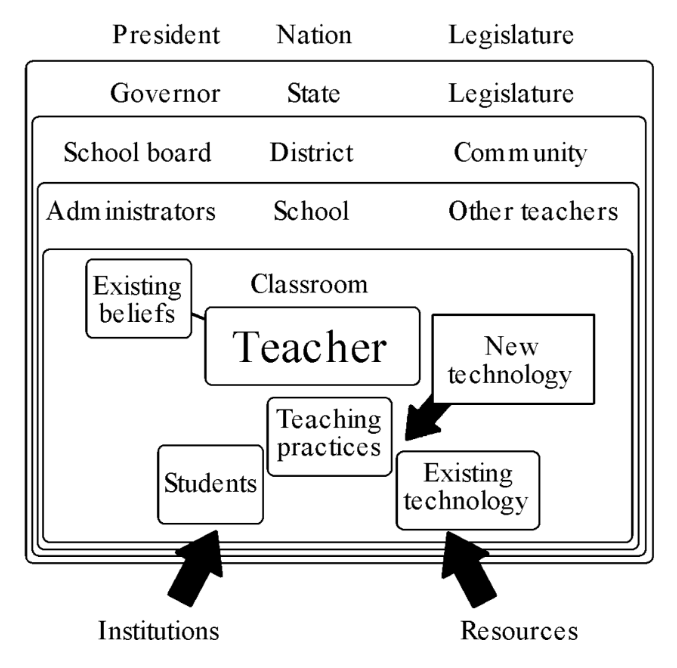

<sup>1</sup>

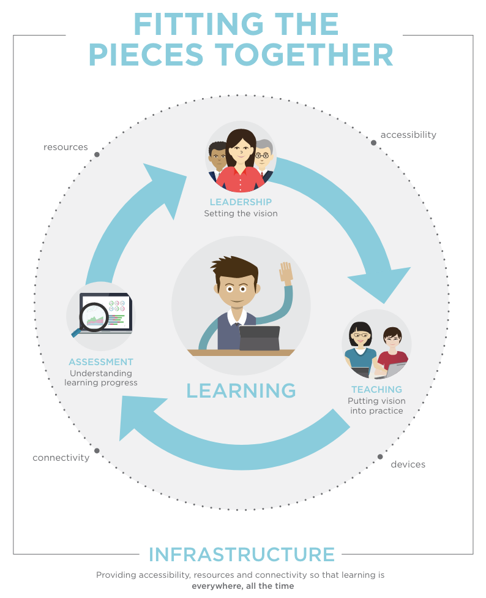

<sup>2</sup>

[^1]: Zhao et al., 2003
[^2]: Office of Ed Tech

## AERA 2018 Presidential Session

[figure not shown]

<sup>1</sup>

**[Evolving Knowledge Infrastructures in Education: Engaging Diversity, Illuminating Inequities, and Imagining Possible Futures](https://convention2.allacademic.com/one/aera/aera18/index.php?program_focus=view_session&selected_session_id=1389607&cmd=online_program_direct_link&sub_action=online_program)**

There is a growing call in Information Sciences for “knowledge infrastructures” (KIs) to debalkanize scholarship, support inter-professional learning, enable distributed collaboration, and capitalize on economies of scope and scale. While infrastructures abound in education—from common standards to technology-enhanced learning environments–comparative critical questions about alternatives and their consequences are rare. A recent multi-disciplinary KI conference asked: (1) How are KIs changing? (2) How do KIs reinforce or redistribute authority, influence, and power? (3) How can we best study, know, and imagine today’s (and tomorrow’s) KIs?

Chair: Pamela A. Moss. Panelists: John Q. Easton, Adam Gamoran, Louis M. Gomez, Kris Gutiérrez, Steven Jackson, Carl Lagoze, Carol D. Lee, Daniel A. McFarlan

[^3]: Happening in Philadelphia this year

## Infrastructure

Invisible

[figure not shown]

Relational

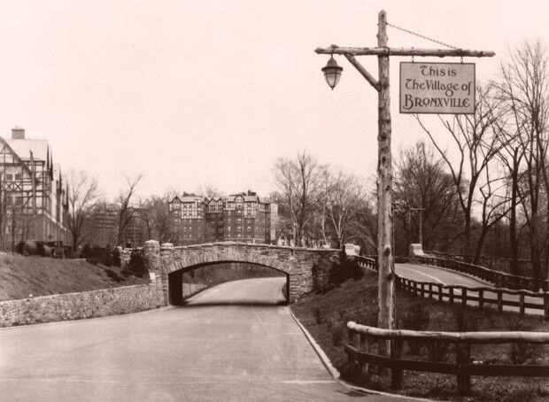

(See [Robert Moses and His Racist Parkway, Explained.](https://www.bloomberg.com/news/articles/2017-07-09/robert-moses-and-his-racist-parkway-explained?embedded-checkout=true))

## Knowledge Infrastructures (KI)

### Paul Edwards, et al.

A Vast Machine: Computer Models, Climate Data, and the Politics of Global Warming

[figure not shown]

Knowledge Infrastructures: Intellectual Frameworks and Research Challenges

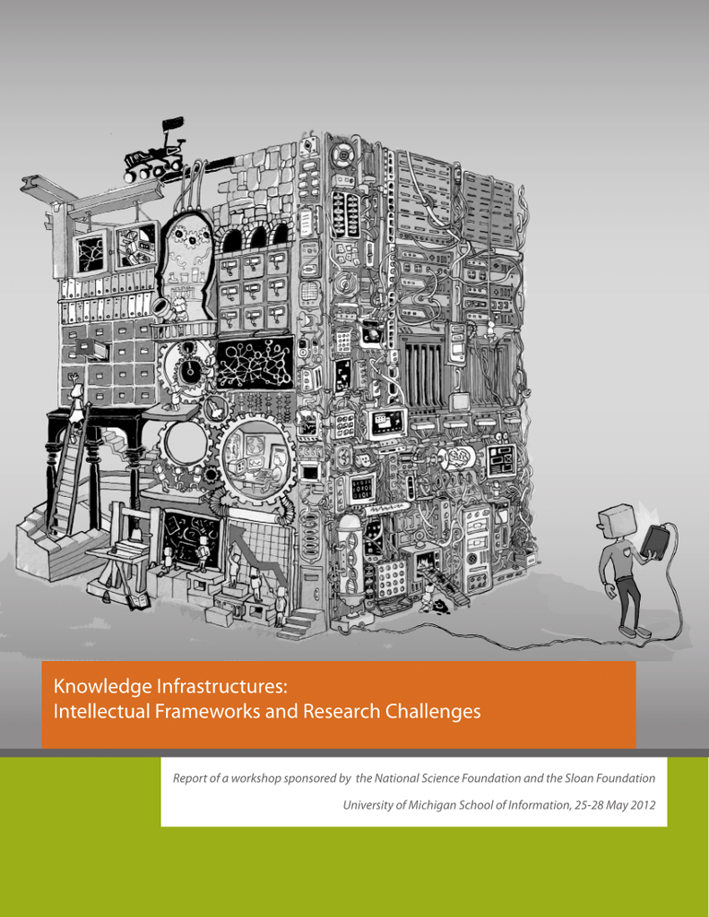

## Knowledge Infrastructures (KI)

> “robust networks of people, artifacts, and institutions that generate, share, and maintain specific knowledge about the human and natural worlds.”

> Routine, well-functioning knowledge systems include the world weather forecast infrastructure, the Centers for Disease Control, or the Intergovernmental Panel on Climate Change — individuals, organizations, routines, shared norms, and practices.

Edwards, P., Jackson, S., Chalmers, M., Bowker, G., Borgman, C., Ribes, D., Calvert, S., & others. (2013). Knowledge infrastructures: Intellectual frameworks and research challenges. Deep Blue.

## KI of Education

Infrastructure for day-to-day educational activities

- Powerschool
- Schoology, Canvas, Seesaw
- Teachers Pay Teachers
- MagicSchool
- …

Infrastructure for knowing whether activities are effective

- Standardized tests
- Course evaluations
- Learning analytics
- …

## Insights from the panel

The slide was created with assistance from whisper.cpp and ChatGPT.

### Pamela Moss

- Knowledge infrastructures are robust networks of people, artifacts, and institutions that generate, share, and maintain specific knowledge.
- Important to study and design knowledge infrastructures, especially given current technological advancements.
- Knowledge infrastructures are not neutral and can impact different stakeholders differently.
- There is much work by various theorists and researchers in this area.

### Steven Jackson

- Discussed the background and evolution of the concept of knowledge infrastructures.
- Described the goal of gathering historical and sociological insights to inform decisions about current infrastructures.
- Highlighted the importance of understanding negative consequences alongside positive developments in infrastructures.
- Discussed key findings from history and sociology of technology, including path dependency and scaling of infrastructures.
- Mentioned the role of standards and gateways in infrastructural development.
- Emphasized the need to consider inclusion and exclusion in infrastructure design.
- Discussed the problem of incumbency and its impact on innovation.
- Shared updates on current work related to standards, innovation, collaboration, improvisational learning, and sustainability in knowledge infrastructures.
- Concluded with a reflection on the importance of maintenance, repair, and ongoing human effort in sustaining knowledge infrastructures.

### John Q. Easton, Spencer Foundation

- Research Practice Partnerships (RPPs): Emphasizes the importance of RPPs, which are collaborations between researchers and practitioners, as a way to increase research use and address educational challenges.
- Characteristics of RPPs: Identified five major characteristics of RPPs: mutualism, focus on specific problems, long-term commitment, intentional partnership efforts, and original research.
- Shift in Research Use: Recognizes a shift from a traditional “research to practice” model to a more interactive and collaborative model, emphasizing continuous improvement research and collaborative problem-solving.
- Infrastructure and Prestige: Notes the strong infrastructure and prestige attached to traditional research methods, highlighting the need for new approaches that bridge research and practice.
- Future Directions: Calls for continued efforts to build infrastructure for RPPs, develop new training programs, establish quality standards, and explore commonalities between different research approaches to improve educational outcomes.

### Adam Gamoran, William T. Grant Foundation

- Focused on the use of evidence from research for policy and practice, particularly in education, highlighting the importance of creating knowledge infrastructures that distribute rather than concentrate knowledge, authority, and power.
- Noted that while the supply of research evidence has greatly improved, the real challenge lies in the quality of relationships between producers and consumers of evidence, advocating for sustained relationships and partnerships to promote trust and evidence use.
- Presented examples of initiatives aimed at democratizing evidence, such as the Institutional Challenge Grant and rapid research response grants, which promote partnerships between researchers and public agencies or nonprofits to jointly construct research agendas and apply existing research to pressing issues.
- Argued that a knowledge infrastructure that distributes authority, influence, and power requires deliberate structuring, joint pursuit of knowledge, and shared engagement between researchers and policymakers or practitioners.

### Kris Gutiérrez

- Advocated for designing knowledge infrastructures with input from communities that are often the subjects of analysis but not typically involved in decision-making.
- Highlighted the need to study how knowledge infrastructures reinforce or redistribute authority, influence, power, and control.
- Criticized the focus on the ubiquity of the internet, pointing out that many families cannot afford broadband access, which exacerbates inequality.
- Emphasized the importance of understanding the knowledge, values, and practices of non-dominant communities in the context of knowledge infrastructures.
- Presented a social design-based approach to research that foregrounds equity, historicity, and specificity of context, aiming to create horizontal networks of collaboration.

### Carol Lee

- Highlighted the importance of understanding the warrants for knowledge production and the ideological foundations of knowledge.
- Criticized the current focus on poverty as a replacement for race in research, calling for more nuanced approaches.
- Raised concerns about policy-making processes and the influence of power dynamics in research funding decisions.
- Emphasized the complexity of human learning and development, advocating for a multidisciplinary approach.
- Stressed the importance of context in understanding human functioning and critiqued oversimplified views in research.

### Daniel A. McFarlan

- Study of Knowledge Infrastructures: The speaker focuses on studying knowledge infrastructures, particularly in higher education contexts, such as interdisciplinary centers, universities, social intellectual movements, schools of thought, and fields like education.
- Reflexive Capacity: Studying knowledge infrastructures provides a reflexive capacity to be intelligent about designing and implementing infrastructures effectively.
- Challenges of Studying Knowledge Infrastructures: Studying knowledge infrastructures at scale presents challenges due to their complexity and fuzziness, requiring new empirical approaches.
- Case Study of Interdisciplinary Institutes: The speaker presents a case study of interdisciplinary institutes at Stanford University, showing how organizational rules, organic collaboration, seed funding, technology access, shared space, and visibility contribute to their success in changing research practices.
- Field-Level Study of Education: The speaker discusses a study of the field of education using big data and natural language processing to identify sub-languages, research clusters, and changes in research trends and power dynamics over time.
- Translational Research at Scale: The speaker introduces the idea of studying translational research pathways at scale, aiming to identify pathways from basic research to practice and develop models for understanding these pathways.

### Panel Discussion

- Inclusive Knowledge Infrastructure: Participants emphasized the importance of constructing knowledge infrastructures that are inclusive and representative of non-dominant communities, including indigenous peoples and marginalized groups.
- Responsibility of Researchers: Researchers were urged to document the variation and kinds of knowledge and practices that communities have. They discussed the need for researchers to contribute to the knowledge base in a way that makes visible the inequities in whose knowledge gets taken up by academia.
- Transdisciplinary Approach: There was a call for a transdisciplinary approach, working across networks, fields, and in large teams to address the complexities of knowledge infrastructure and avoid perpetuating silos in academia.
- Resisting Profit Motives: Participants discussed the challenges of profit motives in knowledge infrastructure and highlighted the importance of resisting the urge to prioritize profit over the public good. They mentioned examples like Cambridge Analytica and net neutrality as instances where profit motives have corrupted the noble ambition of creating information infrastructure.
- Changing Teaching Practices: The discussion touched on how the understanding of infrastructure should change teaching practices, emphasizing the role of teachers in making infrastructures work in the classroom and the need for broader recognition of their contributions.

Overall, the panel underscored the need for more inclusive, equitable, and transparent knowledge infrastructure, emphasizing the role of researchers, educators, and communities in shaping these structures.

## Is education transitioning to a new KI?

### [A clip from the AERA panel discussion](https://www.youtube.com/embed/riKN6FR4mfQ?si=wU4ARHzaoYXZFLst&start=6934)

[video not shown]

## Group Discussion

Consider design projects that members of your group are working on.

Discuss:

1. How are knowledge infrasctrures (KIs) in education currently changing?
2. How is your innovation situated in the current change?
3. How may your innovation attempt to reinforce or redistribte authority, influence, and power?

Record your ideas on FigJam: https://bit.ly/eden-jam-2403  
(Password: eden)

# Lightning Talks: Panel #3

[Google Slides](https://docs.google.com/presentation/d/1DUa5ShgZGcKd_HTpHakhRBkruRbsPW3IWXwhRGe_r4M/edit#slide=id.p)

# Systems and Infrastructures

Anchor texts:

- A framework for on systemic technology innovations (Fishman et al., 2004)
- Infrastructuring as a practice for supporting equity and sustainability (Penuel, 2019)

## Pasteur’s Quadrant

[figure not shown]

### For Education

- Research-based educational intervention in specific contexts to establish sustainable practices
- Tools built to formally analyze processes and outcomes and deployed to shape learning outcomes

## Pasteur’s Quadrant

### Tackle “dilemmas of practice”

An example “dilemma of practice”<sup>1</sup>

- Adopting more ambitious next-generation standards,
- while taking “curriculum-free” state tests

More work needs to embrace “dilemmas of practice”:

> “advance fundamental understandings at the same time that they would work to solve practical problems in real-world settings”

Produce more readily “usable knowledge” and solutions

[^4]: Lorrie Shepard (2000)

## A framework for systemic technology innovations

### (Fishman et al., 2004)

- Cognitively oriented technology innovations could be more broadly used.
- Lacks a bridge between focused research and the development and use of learning technologies.
- Innovations are not sustained beyond researcher involvement.
- Alignment is a challenge and key for sustainability.
- No technology innovation, no matter how compelling or well conceived, will become broadly used and sustained without attending to the issues surrounding the “dilemmas of practice.”

## A framework for systemic technology innovations

### Assess and increase the usability of innovations

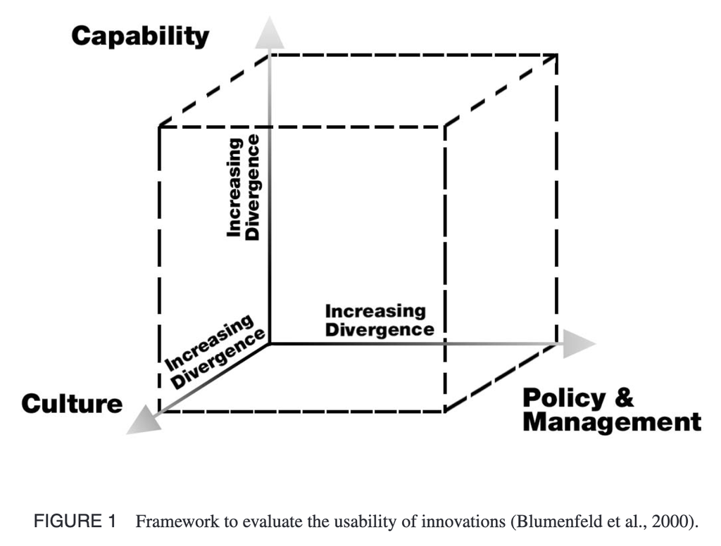

> the space in the cube defines the “capability gap,” “culture gap,” and “policy and management gap” inherent in the innovation

## A framework for systemic technology innovations

### fidelity vs. mutual adaptation

> The fidelity perspective seeks to keep innovations intact…

> The mutual adaptation perspective… recognizes the importance of local re-invention of innovations…

> We shifted our perspective towards mutual adaptation. In doing so, we faced an inherent challenge of this approach – variations that cause innovations to become very different than originally envisioned, potentially weakening the impact of the innovation (McLaughlin, 1990).

> How can researchers create flexibility in their innovations to allow for mutual adaptation that preserves core principles?

## A framework for systemic technology innovations

### partnerships

- All parties must own and be committed to the innovation
- Establishing trust with schools, for bringing multiple viewpoints to inform strategy, for opening doors to solve problems, and for creating specialized professional development programs to serve teachers

## Infrastructuring as a practice (Penuel, 2019)

### Infrastrcture as verb

- Object/Product — Process
- Users — Designers
- Product delivery — Ongoing work to make the innovation work

## Infrastructuring as a practice (Penuel, 2019)

### Components of Educational Infrastructures

- standards for student learning;
- curriculum materials;
- student assessments;
- teacher professional development;
- instructional techniques and routines (e.g., for promoting productive talk in classrooms);
- building- and district-level policies (e.g., regarding the posting of standards, submission of lesson plans that follow a particular format);
- school schedules that allocate instructional time for different subjects;
- roles and positions focused on instructional support (e.g., coaches);
- organizational routines, such as grade-level meetings, in which instruction is a focus; and
- personnel evaluation systems, including the forms of evidence that contribute to assessment of a teacher’s performance

## Infrastructuring as a practice (Penuel, 2019)

- Aims at much more than sustaining a single innovation
- Discovers conditions for sustaining a particular innovation
- Needs coherence-making actions
- Leads to redesign of existing infrastructures or creation of new ones
- Infrastructuring takes time

## IMPROV Framework (Chen, 2024)

1. Identify key social actors and design areas
2. Make visible existing infrastructures
3. Plan for possible points of infrastructuring
4. Rally for coherence-making and infrastructure remaking activities
5. Orchestrate meta-design and capacity building
6. Evaluate infrastructures continually

## Group Discussion

Consider design projects that members of your group are working on.

Discuss:

1. How “usable” is the annotation for its users, based on the usability cube model?
2. How would you increase its usability, by closing “the capability, culture, or policy and management gaps?
3. What infrastructural components need to be redesigned or created?

Record your ideas on FigJam: https://bit.ly/eden-jam-2403  
(Password: eden)

# Lightning Talks: Panel #4

[Google Slides](https://docs.google.com/presentation/d/1DUa5ShgZGcKd_HTpHakhRBkruRbsPW3IWXwhRGe_r4M/edit#slide=id.p)

# Future Weeks

## Upcoming Assignment: Design Project

### Dates and milestones

- April 12: Submit a draft document with key components
- April 19: Share work-in-progress design solution with peers
- May 10: Final design project due

# See You in April!

EDEN 5050